# Tree-Based Models

Catalina Valencia

**Project:** US Crime Rate Modeling: Regression, Regularization, and Tree-Based Methods

**File:** 05_tree_based_models.Rmd

### Objectives:

- Explore non-linear and interaction effects in US crime data.
- Fit and evaluate regression tree models.
- Fit and evaluate random forest models.
- Compare predictive performance and key variable importance.

### Notes:

- Regression trees provide interpretable branching rules but can overfit.
- Pruning mitigates overfitting and improves generalization.
- Random Forest aggregates multiple trees to stabilize predictions and reduce variance.
- Emphasis is on predictive accuracy and qualitative insights, not formal inference.

Environment Setup

```r
rm(list = ls())
set.seed(3)
```

Load required libraries

```r
library(tree)
library(randomForest)
```

Load Data

```r
uscrimedata <- read.table(
  "../data/uscrime.txt",
  header = TRUE,
  stringsAsFactors = FALSE
)
```

Split Data into Training and Test Sets

```r
n <- nrow(uscrimedata)
train_idx <- sample(1:n, size = 0.7 * n)
train <- uscrimedata[train_idx, ]
test  <- uscrimedata[-train_idx, ]
```

### Regression Tree Model

Fit regression tree on training data

```r
tree_model <- tree(Crime ~ ., data = train)
summary(tree_model)
```

```
##
## Regression tree:
## tree(formula = Crime ~ ., data = train)
## Variables actually used in tree construction:
## [1] "Po1"  "Pop"  "LF"   "Time" "NW"
## Number of terminal nodes:  6
## Residual mean deviance:  36320 = 944300 / 26
## Distribution of residuals:
##     Min.  1st Qu.   Median     Mean  3rd Qu.     Max.
## -446.200  -96.950    1.871    0.000  140.900  281.800
```

Plot tree

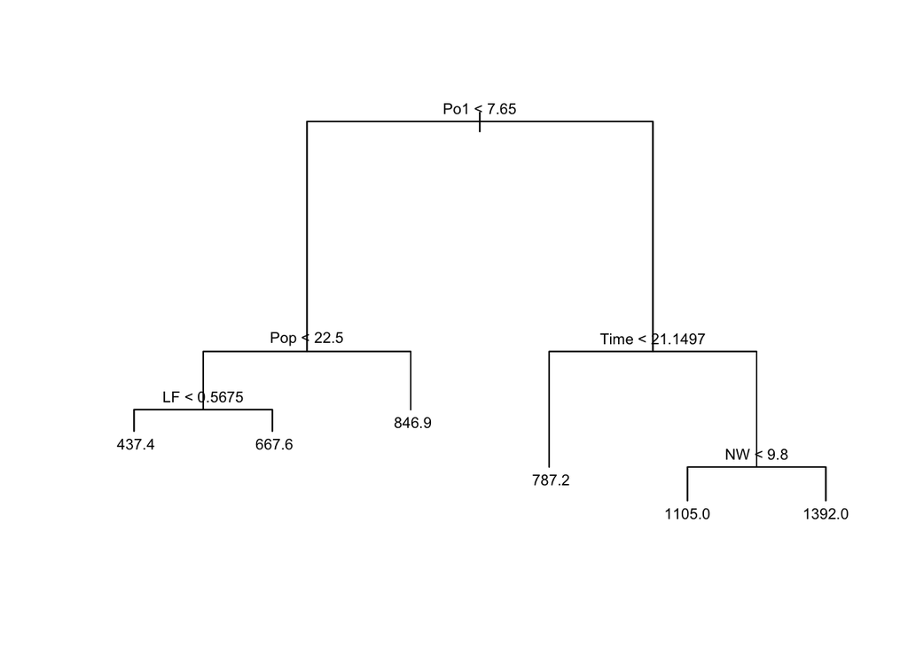

```r
if (nrow(tree_model$frame) > 1) {
  plot(tree_model)
  text(tree_model, cex = 0.7)
}
```

**Cross-validation to determine optimal tree size**

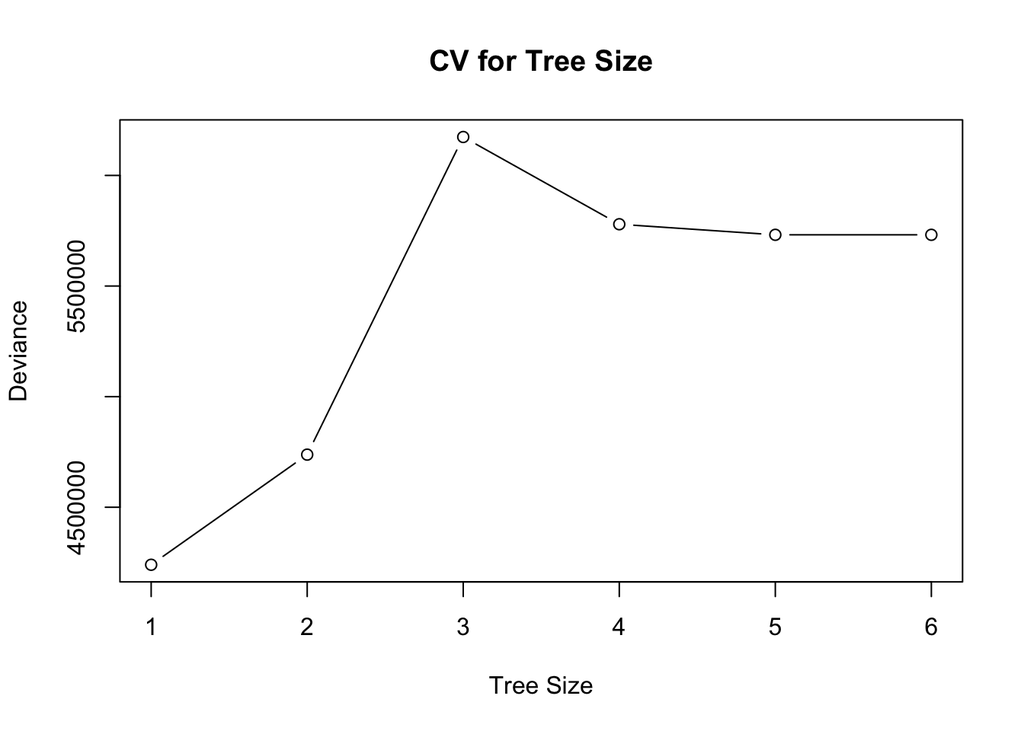

```r
cv_tree <- cv.tree(tree_model)
plot(cv_tree$size, cv_tree$dev, type = "b",
     xlab = "Tree Size", ylab = "Deviance",
     main = "CV for Tree Size")
```

```r
best_nodes <- cv_tree$size[which.min(cv_tree$dev)]
best_nodes
```

```
## [1] 1
```

Prune tree to optimal size

```r
pruned_tree <- prune.tree(tree_model, best = best_nodes)
summary(pruned_tree)
```

```
##         Length Class      Mode
## frame    5     data.frame list
## where   32     -none-     numeric
## terms    3     terms      call
## call     3     -none-     call
## y       32     -none-     numeric
## weights 32     -none-     numeric
```

Plot tree

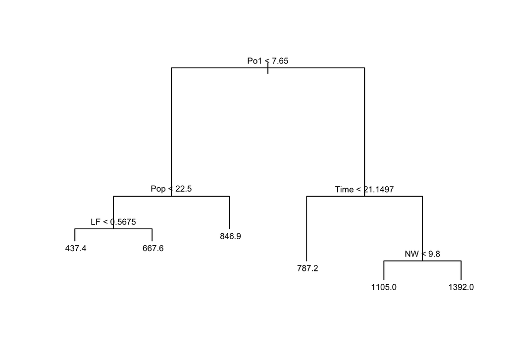

```r
plot(tree_model)
text(tree_model, cex = 0.7)
```

Predictions on test set

```r
yhat_tree <- predict(tree_model, newdata = test)
if (nrow(pruned_tree$frame) > 1) {
  yhat_pruned <- predict(pruned_tree, newdata = test)
  rmse_pruned_tree <- sqrt(mean((test$Crime - yhat_pruned)^2))
} else {
  yhat_pruned <- rep(mean(train$Crime), nrow(test))
  rmse_pruned_tree <- sqrt(mean((test$Crime - yhat_pruned)^2))
}
```

Compute RMSE

```r
rmse_tree <- sqrt(mean((test$Crime - yhat_tree)^2))
rmse_pruned_tree <- sqrt(mean((test$Crime - yhat_pruned)^2))
```

**Results:**

Test RMSE shows slight improvement after pruning:

Full tree: 374.698

Pruned tree: 371.086

- Tree captures non-linear interactions among predictors.
- Pruning reduces overfitting while maintaining predictive accuracy.
- Key insight: lower Po1 values are associated with lower predicted crime rates.

### Random Forest Model

Fit random forest model on training data

```r
rf_model <- randomForest(Crime ~ ., data = train, mtry = 4, importance = TRUE)
rf_model
```

```
##
## Call:
##  randomForest(formula = Crime ~ ., data = train, mtry = 4, importance = TRUE)
##                Type of random forest: regression
##                      Number of trees: 500
## No. of variables tried at each split: 4
##
##           Mean of squared residuals: 79135.76
##                     % Var explained: 32.68
```

Predictions on test set

```r
yhat_rf <- predict(rf_model, newdata = test)
rmse_rf <- sqrt(mean((test$Crime - yhat_rf)^2))
```

Results:

Random Forest model details:

Number of trees: 500

Number of predictors tried at each split (mtry): 4

Test RMSE: 354.663

Visualize variable importance

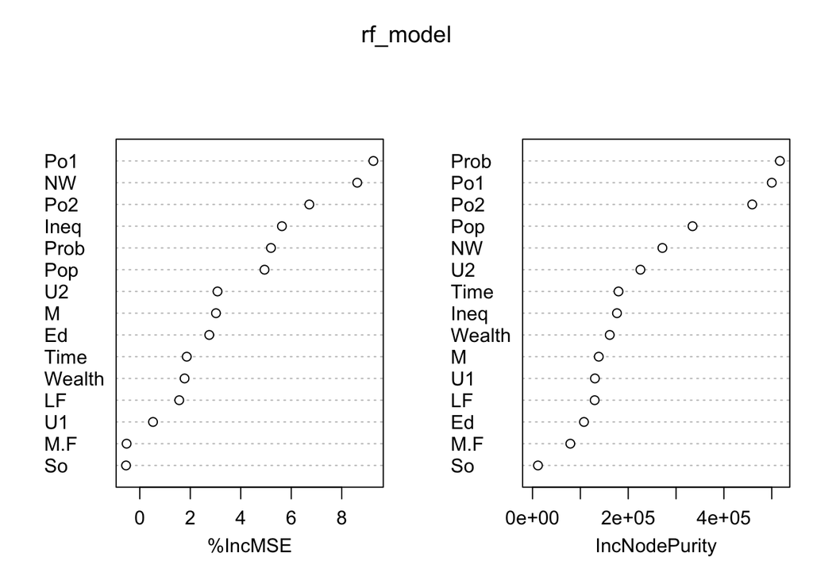

```r
varImpPlot(rf_model)
```

### Conclusion

Tree-based models were used to capture non-linear relationships in the US crime data. A single regression tree offered interpretability but limited predictive accuracy, even after pruning.

Overall, tree-based methods enhance predictive performance and reveal complex structure but are better suited for prediction than formal inference in this study.